# Homework 2

Author

Affiliation

Nicholas Adu Gyamfi

Old Dominion University

Besides New Hampshire and Virginia[^1], car insurance is mandated in every state. The point of this policy is to protect citizens from the often large financial burden resulting from a car crash. However, forcing individuals to purchase insurance may generate negative outcomes through unintended consequences. The often cited reason for this is **moral hazard**. In other words, if individuals are shielded from the negative consequences of dangerous behavior, they may be more likely to engage in such behavior. Think of this from the opposite point of view: if you knew your vehicle would blow up if you got into a fender bender, you’d probably drive much more safely (or not at all) than you do now.

In this homework, we are going to explore the question: **how does auto insurance affect traffic safety?**

There are many ways to think through this problem, but let’s start with the following factors that might be related to auto insurance and traffic safety:

- **Auto Insurance (AI)**: whether an individual has auto insurance (*treatment*).
- **Risky Driving Behavior (RDB)**: an individual’s behavior, such as reckless driving, texting and driving, etc.
- **Vehicle Safety Features (VSF)**: the number of advanced vehicle safety features.
- **Traffic Enforcement (TE)**: the degree to which traffic law enforcement pays attention to the routes the individual travels.
- **Age (A)**: the individual’s age.
- **Crash Risk (CR)**: the probability of being involved in an accident (*outcome*).

Now, consider the following relationships between the variables:

- We will test both the direct and total effect of auto insurance on crash risk.
- Auto insurance, through moral hazard, effects the risky driving behavior of individuals.
- Risky driving behavior will effect the probability of a crash.
- Driver age will effect crash risk due to age alone (*i.e.* inexperience) and due to different levels of risky driving behavior.
- Traffic enforcement will influence risky driving behavior.
- Traffic enforcement will influence crash risks by itself by pulling over *other* reckless drivers.
- Vehicle safety features (due to moral hazard) will influence risky driving behavior.

## Question 1

Using `dagitty`, Construct and plot a DAG to depict the relationships between these variables. Be sure to indicate which variable is the outcome and which is the treatment. (**4 Points**)

```r
## How does Auto Insurance (AI) affect traffic safety
library(dagitty)

dag <- dagitty("dag{
        AI [exposure]
        CR [outcome]

        AI -> CR
        AI -> RDB
        RDB -> CR
        A -> CR
        A -> RDB
        TE -> RDB
        TE -> CR
        VST -> RDB
}");
plot(dag)
```

**Plot**

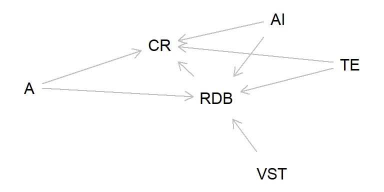

## Question 2

Simulated data for this setting can be found [here](https://alexcardazzi.github.io/econ708/data/autoinsurance_sim.csv).

1. Read the data into an object called `safety` in R. (**1 Point**)

```r
safety <- read.csv("https://alexcardazzi.github.io/econ708/data/autoinsurance_sim.csv")
```

2. Create summary statistics using functions from the `modelsummary` package. (**1 Point**)

```r
library("modelsummary")
datasummary_skim(safety)
```

|  | Unique | Missing Pct. | Mean | SD | Min | Median | Max |  |
| --- | --- | --- | --- | --- | --- | --- | --- | --- |
| AI | 2 | 0 | 0.5 | 0.5 | 0.0 | 0.5 | 1.0 |  |
| VSF | 6 | 0 | 2.4 | 1.4 | 0.0 | 2.0 | 5.0 |  |
| A | 35 | 0 | 32.1 | 10.3 | 16.0 | 32.0 | 50.0 |  |
| TE | 89 | 0 | 0.5 | 0.3 | 0.0 | 0.5 | 1.0 |  |
| RDB | 300 | 0 | −13.6 | 7.4 | −31.0 | −13.3 | 3.7 |  |
| CR | 300 | 0 | 0.4 | 0.2 | 0.0 | 0.5 | 1.0 |  |

## Question 3

Use functions from `dagitty` to evaluate and explore your DAG. This will help inform your empirical specification and identification strategy. You may use code, words, or both to answer these questions.

1. List each of the paths in the DAG and tell which are “open”. (**1 Point**)

```r
plot(dag)
data.frame(paths(dag))
```

**Output**

```
                  paths  open
1              AI -> CR  TRUE
2       AI -> RDB -> CR  TRUE
3  AI -> RDB <- A -> CR FALSE
4 AI -> RDB <- TE -> CR FALSE
```

**Plot**

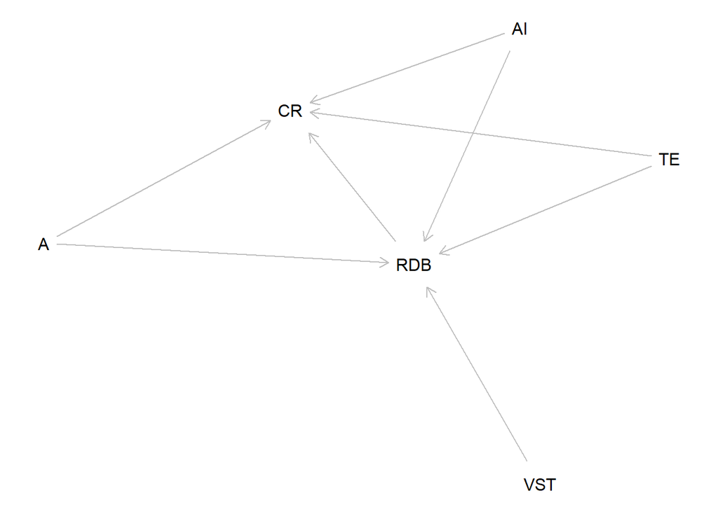

2. For each path, discuss why it is open or closed. Be sure to use terms like “confounder”, “collider”, “mediator”, etc. (**2 Points**)

AI -> CR: This path is open. This shows that AI has a direct influence on CR.

AI -> RDB -> CR: The path from Auto Insurance, Risk Driving Behavior and Crash Risk is open. The arrow from AI to RDB indicate a direct causal relationship between AI and RDB. The second arrow from RDB to CR also indicate a direct causal relationship along the same path. Since both arrows point in the same direction from AI to CR, this path is open. Note that RDB is a mediator between the treatment variable AI and the outcome variable CR.

AI -> RDB <- A -> CR: This path depicts a closed path from the treatment variable AI to the output variable CR. In this path RDB is a collider as the causal relationship depicts. AI has a direct influence on RDB. similarly A has a direct influence on RDB. This introduces a potential confounding factor in the relationship between RDB and CR. However since there is a collider -> RDB <- in the path we leave it as it is as this path is closed.

AI -> RDB <- TE -> CR This path depicts a closed path from the treatment variable AI to the output variable CR. In this path RDB is a collider as the causal relationship depicts. AI has a direct influence on RDB. similarly TE has a direct influence on RDB. This introduces a potential confounding factor in the relationship between RDB and CR. However since there is a collider -> RDB <- in the path we leave it as it is as this path is closed.

3. What does it mean, and why is it significant, for a path to be open/closed? (**1 Point**)

In causal relationships, paths are crucial concepts that help researchers identify potential confounding variables and understand the flow of causal information between variables. An open path is an unblocked pathway between two variables in a DAG. Open paths indicate potential confounding. Identifying open paths guides the selection of adjustment sets to close those paths and control for confounding.

4. Which factors do you need to control for to estimate the *total* causal effect of auto insurance on crash risk? (**1 Point**)

```r
adjustmentSets(dag, effect = "total")
```

**Output**

```
 {}
```

Total causal effect considers the overall impact of one variable on another, taking into consideration all the pathways (direct and indirect) through which the shock is transmitted. To estimate the *total* causal effect of auto insurance on crash risk, we do not have to control for any variables.

5. Which factors do you need to control for to estimate the *direct* causal effect of auto insurance on crash risk? You may use `dagitty` to help you, **but you must provide explanations for `dagitty`’s output**. (**1 Point**)

```r
adjustmentSets(dag, effect = "direct")
```

**Output**

```
{ A, RDB, TE }
```

Direct Causal Effect refers to the immediate influence a variable has on another variable, with no other variables in between them. To estimate the *direct* causal effect of auto insurance on crash risk we need to control for Age(A), Risk Driving Behavior(RDB) and Traffic Enforcement (TE).

## Question 4

Using `safety`, estimate the (direct and total) causal effects of auto insurance on crash risk.

1. Estimate the models below. (**1 Point**)

```r
# Direct Causal Effect
r1 <- lm(CR ~ AI + A + RDB + TE, data = safety)
#summary(r1)

# Total Causal Effect
r2 <- lm(CR ~ AI, data = safety)
#summary(r2)
```

2. Display the coefficient estimates in a table generated via functions in `modelsummary`. (**1 Point**)

```r
regz <- list(`Direct Causal Effect` = r1,
             `Total Causal Effect` = r2)

coefz <- c("CR" = "Crush Risk",
           "AI" = "Auto Insurance",
           "A" = "Age",
           "RDB" = "Risky Driving Behavior",
           "TE" = "Traffic Enforcement",
           "(Intercept)" = "Constant")

gofz <- c("nobs", "r.squared")

modelsummary(regz,
             title = "Effect of auto insurance on traffic safety/Crush Risk",
             estimate = "{estimate}{stars}",
             coef_map = coefz,
             gof_map = gofz)
```

Effect of auto insurance on traffic safety/Crush Risk

|  | Direct Causal Effect | Total Causal Effect |
| --- | --- | --- |
| Auto Insurance | 0.003 | 0.069** |
|  | (0.017) | (0.021) |
| Age | −0.005*** |  |
|  | (0.001) |  |
| Risky Driving Behavior | 0.011*** |  |
|  | (0.002) |  |
| Traffic Enforcement | −0.147*** |  |
|  | (0.029) |  |
| Constant | 0.832*** | 0.408*** |
|  | (0.030) | (0.015) |
| Num.Obs. | 300 | 300 |
| R2 | 0.553 | 0.034 |

3. Interpret each coefficient, besides the intercept/constant, in each model. (**2 Points**)

For Total Causal effect: One unit increase in auto insurance leads to a 0.069 units increase in crush risk. This coefficient is statistically significant.

For Direct Causal effect: Each additional auto insurance purchased leads to a 0.003 units increase in crush risk holding other variables constant. This coefficient is statistically insignificant.

Each additional year of age leads to a 0.005 units reduction in crush risk holding other variables constant. This coefficient is statistically significant.

One unit increase in risky driving behavior leads to a 0.011 units increase in crush risk holding other variables constant. This coefficient is statistically significant.

An increase of one unit in traffic enforcement leads to a 0.147 units reduction in crush risk holding other variables constant. This coefficient is statistically significant.

## Question 5

Consider this question using data in real life. What difficulties might you have in estimating these models in reality? (**2 Points**)

Several difficulties might arise in estimating these models in reality. Some of these include the following:

Error in Measurement:  
Errors in measuring the variables under consideration can introduce bias in the estimated relationships. Error might occur in measuring vehicle safety features, risky driving behavior etc. It may be much difficult to improve the accuracy of some of these measurements in practice.

Confounding Factors:  
It is practically impossible to identify and control for all unobserved confounding factors that influence both the purchase of insurance and crush risk. Not only this omitting relevant confounders can lead to biased estimates.

Availability and Quality of Data:  
Availability and quality of data may be challenging. Variables like risky driving behavior or detailed vehicle safety features may be ambiguous. Not only this, but missing data can also impact quality of the estimated models.

Moral Hazard:  
Moral hazard might occur if individuals with insurance coverage engage in riskier driving behavior than they normally would without insurance. Knowing that insurance will cover some or all of the costs in the event of a crash might lead individuals to be less cautious, such as driving faster or being less attentive.

Endogeneity:  
Endogeneity arises when the variable of interest (Auto Insurance) is correlated with the error term. In this context, individuals with higher crash risk might be more inclined to purchase auto insurance.

## Question 6

Think of two additional variables and/or edges that may belong in this DAG. Make an argument for why they belong in the DAG. (**2 Points**)

Driving Under the Influence (DUI):  
Driving under the influence of alcohol or drugs significantly increases crash risk through Risky Driving Behavior. DUI has a direct causal effect on risky driving behavior and as such needs to be considered in analyzing this DAG.

Weather (W):  
Weather conditions, such as rain, snow, or fog, can contribute to increased crash risk and as such needs to be considered in analyzing this DAG.

Driving Experience (DE):  
The number of years a driver has been licensed and their overall driving experience can impact crash risk.

## Footnotes

[^1]: Virginia allows individuals to opt out of insurance, but they then must pay a $500 uninsured fee.